# p8130_final_project

Brooklynn McNeil

2024-11-25

## Exploratory Analysis and Visualization

The dataset we will be working with is from breast cancer patients. We are interested in predicting the risk of death based on many predictors from societal to genetic makeup.

Let’s read in the data and take a look.

```r
breastcancer_df = read_csv("Project_2_data.csv") |>
  janitor::clean_names() |>
  mutate(sixth_stage = factor(x6th_stage)) |>
  select(-x6th_stage) |>
  mutate(
    status = case_when(
    status == "Alive" ~ 0,
    status == "Dead" ~ 1),
    across(c(race, marital_status, t_stage, n_stage, differentiate, a_stage,
             estrogen_status, progesterone_status, sixth_stage), factor))
head(breastcancer_df)
```

```
# A tibble: 6 × 16
    age race  marital_status t_stage n_stage differentiate         grade a_stage
  <dbl> <fct> <fct>          <fct>   <fct>   <fct>                 <chr> <fct>
1    68 White Married        T1      N1      Poorly differentiated 3     Region…
2    50 White Married        T2      N2      Moderately different… 2     Region…
3    58 White Divorced       T3      N3      Moderately different… 2     Region…
4    58 White Married        T1      N1      Poorly differentiated 3     Region…
5    47 White Married        T2      N1      Poorly differentiated 3     Region…
6    51 White Single         T1      N1      Moderately different… 2     Region…
# ℹ 8 more variables: tumor_size <dbl>, estrogen_status <fct>,
#   progesterone_status <fct>, regional_node_examined <dbl>,
#   reginol_node_positive <dbl>, survival_months <dbl>, status <dbl>,
#   sixth_stage <fct>
```

We have 16 variables relating to these patietns with breast cancer. The dataset includes 3408 individuals that are alive and 616 that are dead. The average age of patients is 54. The races that are considered are White, Black, Other and the marital statuses considered are Married, Divorced, Single, Widowed, Separated.

Let’s look at our variables graphically.

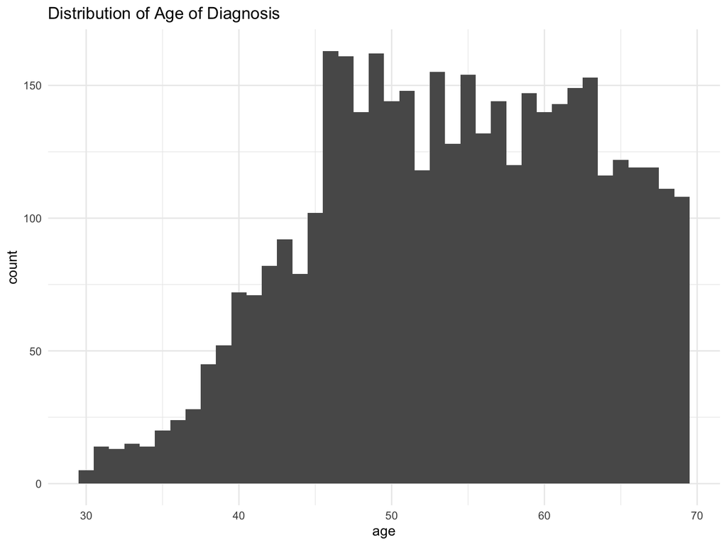

```r
# age distribution
breastcancer_df |>
  ggplot(aes(x = age)) +
  geom_histogram(binwidth = 1) +
  labs(title = "Distribution of Age of Diagnosis")
```

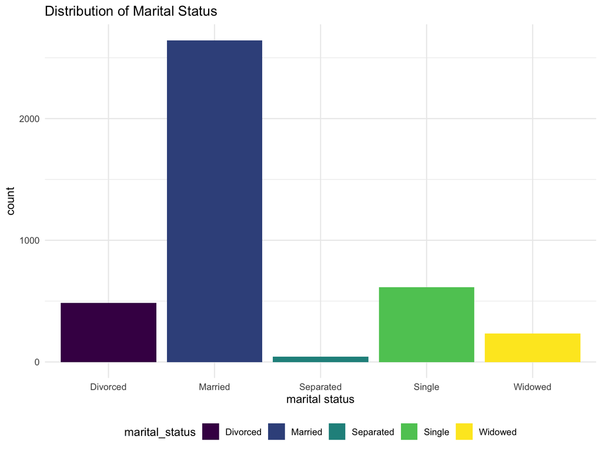

```r
# marital status distribution
breastcancer_df |>
  ggplot(aes(x = marital_status, fill = marital_status)) +
  geom_bar() +
  labs(title = "Distribution of Marital Status",
       x = "marital status")
```

[figure not shown]

```r
# race disbtribution
breastcancer_df |>
  ggplot(aes(x = race, fill = race)) +
  geom_bar() +
  labs(title = "Distribution of Marital Status",
       x = "race")
```

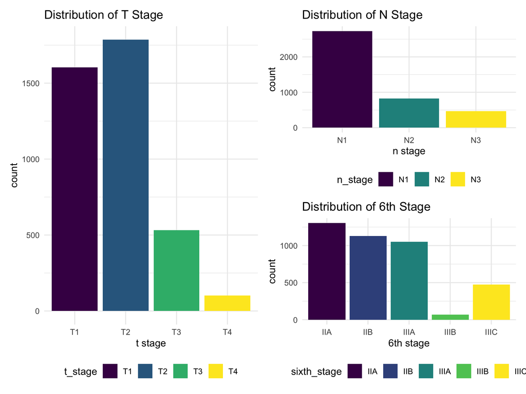

```r
T.stage =
  breastcancer_df |>
  ggplot(aes(x = t_stage, fill = t_stage)) +
  geom_bar() +
  labs(title = "Distribution of T Stage",
       x = "t stage")
N.stage =
  breastcancer_df |>
  ggplot(aes(x = n_stage, fill = n_stage)) +
  geom_bar() +
  labs(title = "Distribution of N Stage",
       x = "n stage")

sixth.stage =
  breastcancer_df |>
  ggplot(aes(x = sixth_stage, fill = sixth_stage)) +
  geom_bar() +
  labs(title = "Distribution of 6th Stage",
       x = "6th stage")

T.stage + N.stage / sixth.stage
```

Now let’s look at the information pertaining to the tumors.

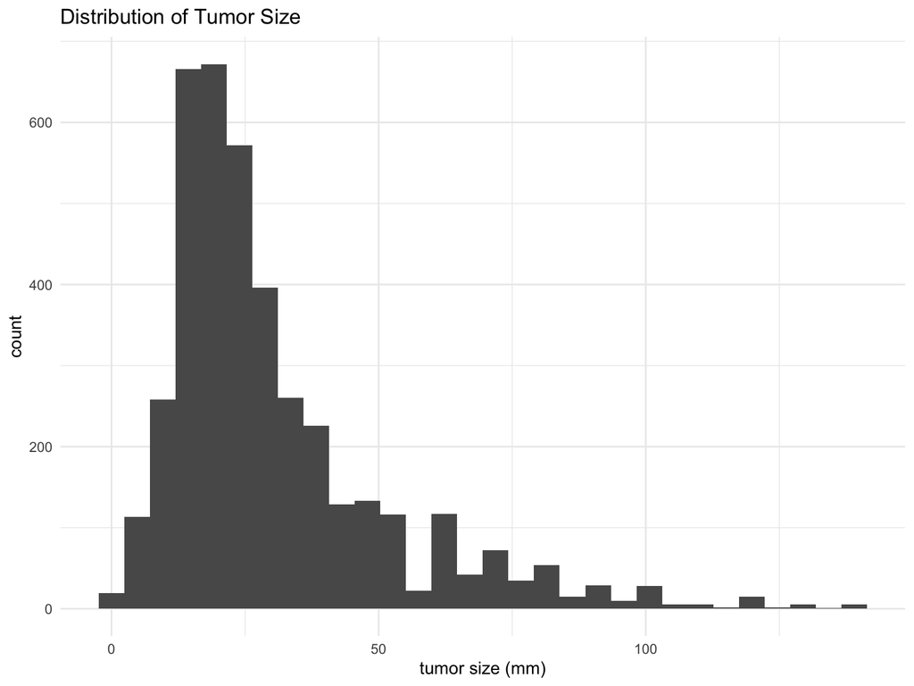

```r
# tumor size
breastcancer_df |>
  ggplot(aes(x = tumor_size)) +
  geom_histogram() +
  labs(title = "Distribution of Tumor Size",
       x = "tumor size (mm)")
```

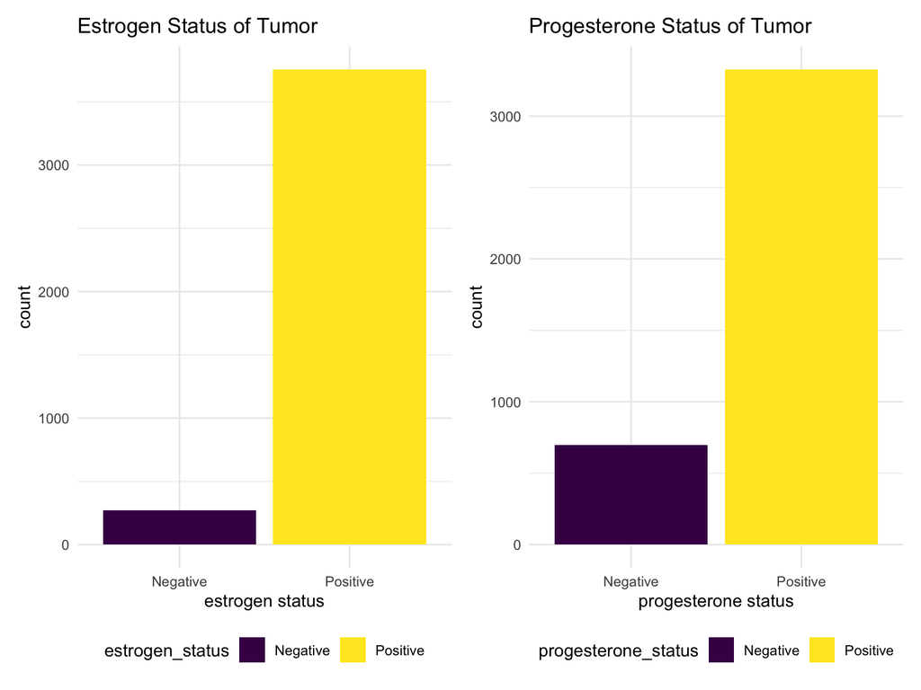

```r
# estrogen status
estrog =
  breastcancer_df |>
  ggplot(aes(x = estrogen_status, fill = estrogen_status)) +
  geom_bar() +
  labs(title = "Estrogen Status of Tumor",
       x = "estrogen status")

# progesterone status
prog =
  breastcancer_df |>
  ggplot(aes(x = progesterone_status, fill = progesterone_status)) +
  geom_bar() +
  labs(title = "Progesterone Status of Tumor",
       x = "progesterone status")

estrog + prog
```

Finally, let’s look at the distribution of the outcome and address linearity.

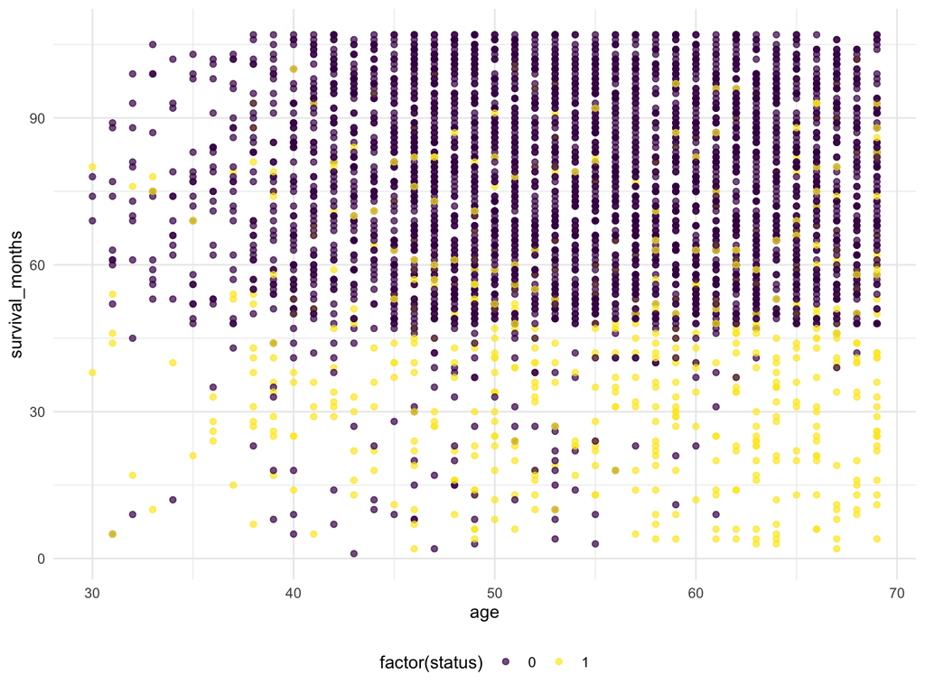

```r
breastcancer_df |>
  ggplot(aes(x = age, y = survival_months, color = factor(status))) +
  geom_point(alpha = 0.7)
```

## Statistical Analysis

```r
# fit a cox regression model

cox_fit = breastcancer_df |>
  coxph(Surv(survival_months,status) ~ age + race, data = _)

cox_fit |>
  broom::tidy() |>
  knitr::kable()
```

| term | estimate | std.error | statistic | p.value |
| --- | --- | --- | --- | --- |
| age | 0.0158849 | 0.0046455 | 3.419385 | 0.0006276 |
| raceOther | -0.9810357 | 0.2098560 | -4.674804 | 0.0000029 |
| raceWhite | -0.6247820 | 0.1253675 | -4.983606 | 0.0000006 |

Let’s check for the assumptions of the cox model.

1. Proportional hazards assumption
   1. the effect of the covariates is constant over time
   2. use `cox.zph()` to test for constant proportions
   3. use `plot(cox.zph())` to plot, but Cox Regression does not depend on linearity.
2. Linear relationship between covariates and log hazards.
   1. asses with scatterplot
3. Independence of survival times
   1. If clustering exists, use a frailty model or robust standard errors to account for dependency.
4. No omitted confounders
   1. assumes we have included all relevant covariates in the model.
5. No multicollinearity.
   1. There should not be high colinearity between covariates.
   2. use `vif()` variance inflation factor >5 indicates multicolinearity.

```r
# check if the assumptions are valid
cox.zph(cox_fit)
```

```
       chisq df    p
age    0.239  1 0.63
race   2.213  2 0.33
GLOBAL 2.462  3 0.48
```

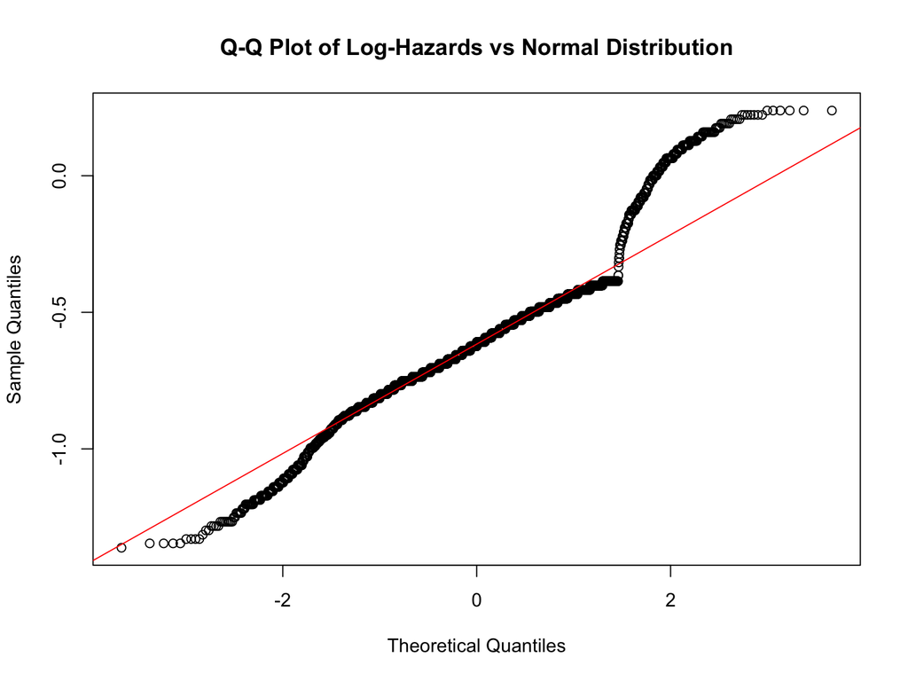

```r
# Extract the linear predictor (log-hazards)
log_hazards <- predict(cox_fit, type = "lp")

# Create a Q-Q plot for log-hazards
qqnorm(log_hazards, main = "Q-Q Plot of Log-Hazards vs Normal Distribution")
qqline(log_hazards, col = "red")
```

```r
# check for mutlicolinearity
vif(cox_fit)
```

```
         GVIF Df GVIF^(1/(2*Df))
age  1.007056  1        1.003522
race 1.007056  2        1.001759
```

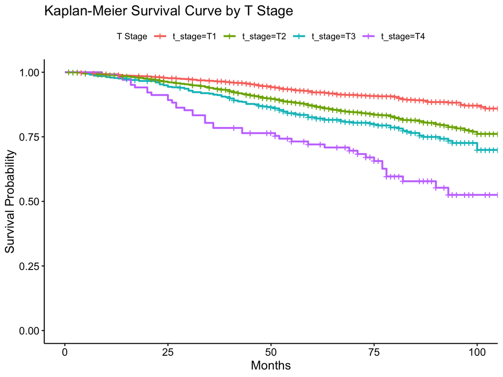

```r
# Kaplan-Meier survival curve by t_stage
km_fit <- survfit(Surv(survival_months, status) ~ t_stage, data = breastcancer_df)

# Plot the survival curves
ggsurvplot(km_fit,
           data = breastcancer_df,
           xlab = "Months",
           ylab = "Survival Probability",
           title = "Kaplan-Meier Survival Curve by T Stage",
           legend.title = "T Stage")
```

Ok, here’s the plan

- map the survival model across all of the individual variables
- rule out the unimportant variables
- start adding in the variables to test if that improves the model (refer to diagnostics lecture)
- test for an increase in adjusted R squared for the best model

Now let’s start with mapping across all variables!!

```r
models_list = list(
  age_mod = coxph(Surv(survival_months, status) ~ age, data = breastcancer_df),
  race_mod = coxph(Surv(survival_months, status) ~ race, data = breastcancer_df),
  marital_mod = coxph(Surv(survival_months, status) ~ marital_status, data = breastcancer_df),
  t_stage_mod = coxph(Surv(survival_months, status) ~ t_stage, data = breastcancer_df),
  n_stage_mod = coxph(Surv(survival_months, status) ~ n_stage, data = breastcancer_df),
  sixth_stage_mod = coxph(Surv(survival_months, status) ~ sixth_stage, data = breastcancer_df),
  dif_mod = coxph(Surv(survival_months, status) ~ differentiate, data = breastcancer_df),
  tumor_mod = coxph(Surv(survival_months, status) ~ tumor_size, data = breastcancer_df),
  region_examined_mod = coxph(Surv(survival_months, status) ~ regional_node_examined, data = breastcancer_df),
  region_pos_mod = coxph(Surv(survival_months, status) ~ reginol_node_positive, data = breastcancer_df),
  a_stage_mod = coxph(Surv(survival_months, status) ~ a_stage, data = breastcancer_df),
  estrogen_mod = coxph(Surv(survival_months, status) ~ estrogen_status, data = breastcancer_df),
  progesterone_mod = coxph(Surv(survival_months, status) ~ progesterone_status, data = breastcancer_df),
  grade_mod = coxph(Surv(survival_months, status) ~ grade, data = breastcancer_df)
)

# Tidy the models and combine into one data frame
single_results <- map_dfr(models_list, broom::tidy, .id = "model")

# View combined results
knitr::kable(single_results)
```

| model | term | estimate | std.error | statistic | p.value |
| --- | --- | --- | --- | --- | --- |
| age_mod | age | 0.0156593 | 0.0046243 | 3.3863224 | 0.0007084 |
| race_mod | raceOther | -0.9978353 | 0.2098027 | -4.7560643 | 0.0000020 |
| race_mod | raceWhite | -0.5997031 | 0.1251601 | -4.7914892 | 0.0000017 |
| marital_mod | marital_statusMarried | -0.3346512 | 0.1179228 | -2.8378850 | 0.0045414 |
| marital_mod | marital_statusSeparated | 0.7483013 | 0.2789638 | 2.6824317 | 0.0073089 |
| marital_mod | marital_statusSingle | -0.0898677 | 0.1439710 | -0.6242071 | 0.5324916 |
| marital_mod | marital_statusWidowed | 0.1376839 | 0.1775401 | 0.7755086 | 0.4380392 |
| t_stage_mod | t_stageT2 | 0.6045621 | 0.0983518 | 6.1469318 | 0.0000000 |
| t_stage_mod | t_stageT3 | 0.8774509 | 0.1224652 | 7.1648995 | 0.0000000 |
| t_stage_mod | t_stageT4 | 1.5301290 | 0.1771492 | 8.6375171 | 0.0000000 |
| n_stage_mod | n_stageN2 | 0.7693455 | 0.0988284 | 7.7846626 | 0.0000000 |
| n_stage_mod | n_stageN3 | 1.5313256 | 0.0961381 | 15.9283873 | 0.0000000 |
| sixth_stage_mod | sixth_stageIIB | 0.5222682 | 0.1335172 | 3.9116169 | 0.0000917 |
| sixth_stage_mod | sixth_stageIIIA | 0.9397571 | 0.1259328 | 7.4623680 | 0.0000000 |
| sixth_stage_mod | sixth_stageIIIB | 1.4959127 | 0.2458173 | 6.0854646 | 0.0000000 |
| sixth_stage_mod | sixth_stageIIIC | 1.8480388 | 0.1263420 | 14.6272730 | 0.0000000 |
| dif_mod | differentiatePoorly differentiated | 0.6592787 | 0.0841566 | 7.8339525 | 0.0000000 |
| dif_mod | differentiateUndifferentiated | 1.4220552 | 0.3382678 | 4.2039336 | 0.0000262 |
| dif_mod | differentiateWell differentiated | -0.6028485 | 0.1700600 | -3.5449172 | 0.0003927 |
| tumor_mod | tumor_size | 0.0133567 | 0.0015211 | 8.7809325 | 0.0000000 |
| region_examined_mod | regional_node_examined | 0.0110171 | 0.0048420 | 2.2753265 | 0.0228863 |
| region_pos_mod | reginol_node_positive | 0.0777658 | 0.0046822 | 16.6087996 | 0.0000000 |
| a_stage_mod | a_stageRegional | -1.1398535 | 0.1740929 | -6.5473865 | 0.0000000 |
| estrogen_mod | estrogen_statusPositive | -1.2994329 | 0.1060498 | -12.2530392 | 0.0000000 |
| progesterone_mod | progesterone_statusPositive | -0.9563847 | 0.0856506 | -11.1661164 | 0.0000000 |
| grade_mod | grade2 | 0.6028485 | 0.1700600 | 3.5449172 | 0.0003927 |
| grade_mod | grade3 | 1.2621271 | 0.1715965 | 7.3552047 | 0.0000000 |
| grade_mod | gradeanaplastic; Grade IV | 2.0249036 | 0.3698552 | 5.4748550 | 0.0000000 |

## Validation

```r
cv_df = crossv_mc(breastcancer_df,10)

cv_df = cv_df |>
  mutate(
    train = map(train, \(i) as.tibble(i)),
    test = map(test, \(i) as.tibble(i))
  ) |>
  mutate(
    age_mod  = map(train, \(df) coxph(Surv(survival_months,status) ~ age, data = df)),
    race_mod = map(train, \(df) coxph(Surv(survival_months,status) ~ race, data = df)),
    marital_mod = map(train, \(df) coxph(Surv(survival_months,status) ~ marital_status, data = df)),
    t.stage_mod = map(train, \(df) coxph(Surv(survival_months,status) ~ t_stage, data = df)),
    n.stage_mod = map(train, \(df) coxph(Surv(survival_months,status) ~ n_stage, data = df)),
    sixth.stage_mod = map(train, \(df) coxph(Surv(survival_months,status) ~ sixth_stage, data = df)),
    dif_mod = map(train, \(df) coxph(Surv(survival_months,status) ~ differentiate, data = df)),
    tumor_mod = map(train, \(df) coxph(Surv(survival_months,status) ~ tumor_size, data = df)),
    region_examined_mod = map(train, \(df) coxph(Surv(survival_months,status) ~ regional_node_examined, data = df)),
    region_pos_mod = map(train, \(df) coxph(Surv(survival_months,status) ~ reginol_node_positive, data = df)),
    a.stage_mod = map(train, \(df) coxph(Surv(survival_months,status) ~ a_stage, data = df)),
    estrogen_mod = map(train, \(df) coxph(Surv(survival_months,status) ~ estrogen_status, data = df)),
    progesterone_mod = map(train, \(df) coxph(Surv(survival_months,status) ~ progesterone_status, data = df)),
    grade_mod = map(train, \(df) coxph(Surv(survival_months,status) ~ grade, data = df)))
```